# Offleaks

This project for Social and Economic Networks course uses Offshore Leaks Database found here https://offshoreleaks.icij.org/.

## Yearly counts development

One would like to know how many accounts have been opened throughout years.

The sample size for answering this question is 202108.

The earliest opened account belongs to 1936 and the latest comes from the future 2020.

The most fruitful years for the offshore accounts are the following:

```
## Source: local data frame [6 x 2]
##
##   incorporation_year     n
##                (dbl) (int)
## 1               2007 17709
## 2               2006 16684
## 3               2005 14868
## 4               2004 13022
## 5               2000 10791
## 6               2008 10404
```

Overall, that is how the process looks like:

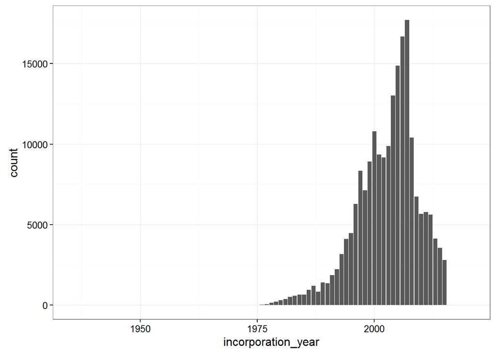

## CEE countries counts

Number of firms related to different Central-Eastern European countries.

```
##
##        Hungary         Poland        Romania        Croatia       Slovenia
##             66            108              4             10             11
##         Serbia Czech Republic        Ukraine        Belarus      Lithuania
##              4            112            313             20             15
##         Latvia        Estonia
##           1951            558
```

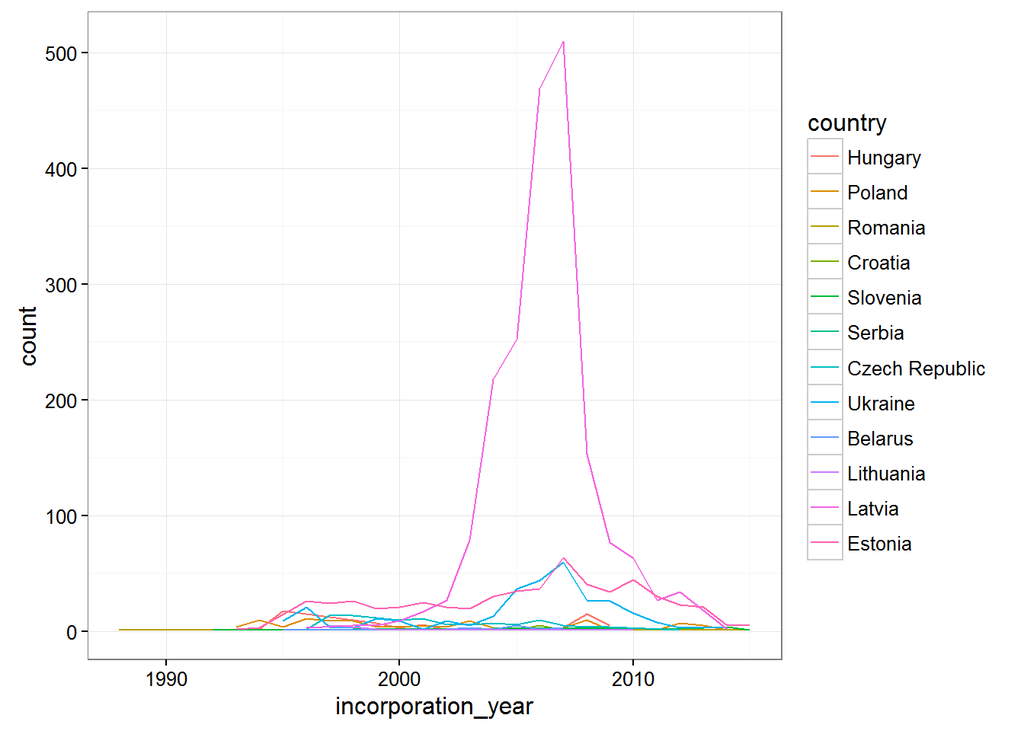

Without Latvia:

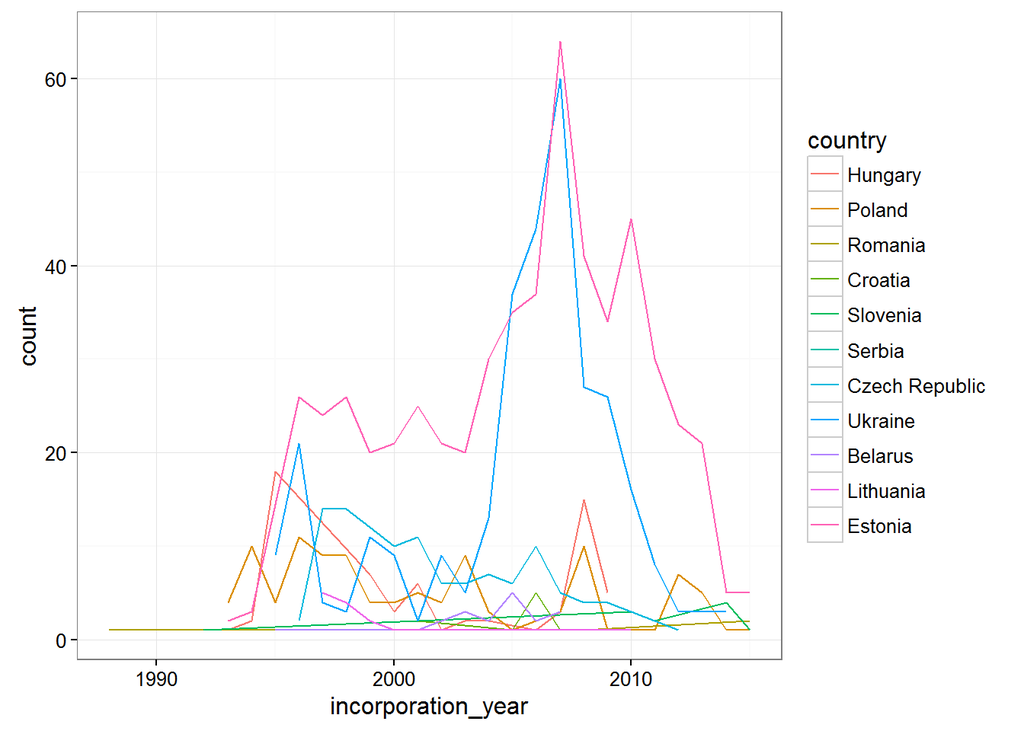

## CEE countries relationships

It is interesting to see how are the relationships built around the entities from these countries.

There are 8786 known links related to CEE countries entities.

The count allocation of the nodes from origin to end is the following:

```
##                 end
## origin           address cee-entity non-cee-entity
##   cee-entity        1308          1              3
##   intermediary         0       3172              0
##   non-cee-entity       0          3              0
##   officer              0       4299              0
```

### “registered address” relationship type

When the origin node is a cee-entity, it points to either addresses or other entities.

When it is a cee-entity connecting to an address, the relationship type of the nodes are registered address. Do the countries of the cee-entity correspond to the address specified?

The mean of matches of the cee-entity and the address countries is:

```
## [1] 1
```

Then these links of type `"cee-entity"-"registered address"-"address"` present no interest for the further study.

### “same name and registration date as” relationship type

Now the amount of links is reduced to 7478.

There are some entites linked to other entites through same name and registration date as.

```
##                 origin   node_1                           rel_type
## 1264595 non-cee-entity 10013420 same name and registration date as
## 1265366 non-cee-entity 10051831 same name and registration date as
## 1267466     cee-entity   197215 same name and registration date as
## 1267521 non-cee-entity   232413 same name and registration date as
## 1267536     cee-entity   232019 same name and registration date as
## 1267573     cee-entity   194308 same name and registration date as
## 1267580     cee-entity   197218 same name and registration date as
##                    end   node_2
## 1264595     cee-entity 10013465
## 1265366     cee-entity 10057348
## 1267466     cee-entity 10141622
## 1267521     cee-entity 10136446
## 1267536 non-cee-entity   232020
## 1267573 non-cee-entity 10131652
## 1267580 non-cee-entity 10138821
```

The assumed way to deal with duplicates in this case is to bring in the edges connected to the found non-cee-entites and replace all instances of `node_2` as `node_1`.

The treatment leads to 7486 distinct link observations.

Now the relationships between the nodes related to CEE countries are as follows:

```
##                      origin
## relationship          intermediary officer
##   beneficial owner of            0       7
##   beneficiary of                 0     116
##   director of                    0    1723
##   intermediary of             3178       0
##   secretary of                   0      15
##   shareholder of                 0    2447
```

## Constructing the network

It is possible now to construct the network.

```
##
##                          Armenia                        Australia
##                                1                               10
##                       Azerbaijan                          Bahamas
##                               17                                4
##                          Belarus                           Belize
##                               32                               49
##           British Virgin Islands                             Chad
##                               89                                1
##                            China                       Costa Rica
##                                7                                1
##                          Croatia                         CuraÃ§ao
##                               20                                1
##                           Cyprus                   Czech Republic
##                               65                              138
##                         Dominica                         DR Congo
##                                1                                3
##                          Estonia                          Finland
##                              604                               16
##                           France                          Georgia
##                                1                                4
##                          Germany                        Gibraltar
##                                7                                6
##                         Guernsey                          Hungary
##                                4                               88
##                            India                             Iran
##                                1                                2
##                           Israel                            Italy
##                                5                                1
##                            Japan                           Jersey
##                                1                               17
##                       Kazakhstan                           Latvia
##                               17                             1987
##                          Lesotho                          Liberia
##                                2                                1
##                            Libya                    Liechtenstein
##                                1                                2
##                        Lithuania                       Luxembourg
##                               22                                1
##                 Marshall Islands                        Mauritius
```

[output cut: 20 more lines]

```
##                                6                                1
##                       Tajikistan                     Turkmenistan
##                                3                                2
##         Turks and Caicos Islands              U.S. Virgin Islands
##                                2                               11
##                          Ukraine             United Arab Emirates
##                              375                               25
##      United Arab Emirates;Cyprus                   United Kingdom
##                                1                               39
##                    United States                       Uzbekistan
##                               11                               10
##                          Vanuatu                         Viet Nam
##                                4                                2
##                             <NA>
##                              715
```

So far by construction the network is bipartite: TRUE.

Below is the first attempt to plot the resulting network.

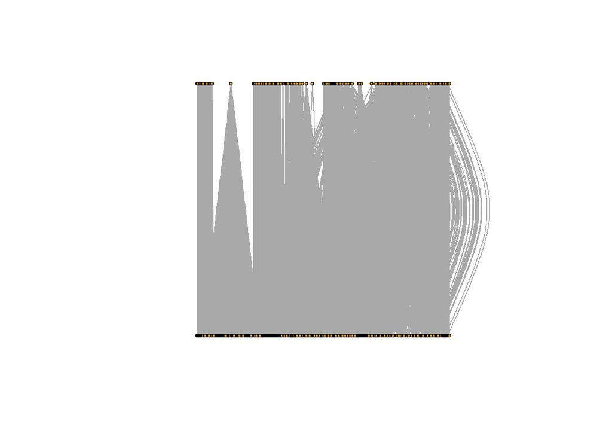

## Nodes decomposed

The main connections file provides 1269796 links/edges. At both ends one can find different players.

### Origin nodes

There are 462468 unique origin nodes/vertices.

They are distributed among the types in the following manner:

| Entities | Addresses | Intermediaries | Officers |
| --- | --- | --- | --- |
| 93572 | 960 | 23600 | 345475 |
| 20.1834744% | 0.2070719% | 5.0905185% | 74.5189352% |

A note. The decomposition does not sum up to the number of unique entries. 463607 = 462468 is FALSE.

### Receiving nodes

Looking at the unique receiving nodes/vertices, one can find that there are 492143 of them.

They are distributed among the types in the following manner:

| Entities | Addresses | Intermediaries | Officers |
| --- | --- | --- | --- |
| 319122 | 151043 | 355 | 21664 |
| 64.8379468% | 30.6883198% | 0.0721275% | 4.4016059% |

In the same manner 492184 = 492143 is FALSE.

### Origins and ends overall

The cross tabulated origins and ends from all the edges available are presented in the table below.

```
##
##                address entity intermediary officer
##   address          960      0            0       0
##   entity         93623   3768            0       0
##   intermediary    9358 362425           21      56
##   officer       213491 538166          349   47579
```